# Plots of Sunspots: A Project in Fulfillment of Course 9 of the Data Science Specialty

September 16, 2017

## Rationale

- Many look at sunspot cycles to study space weather and astronomy.
- Time series of sunspots reveal cyclical patterns.
- Mean relative sunspot numbers from 1749-1983 were collected at the Swiss Federal Observatory until 1960, and then by the Tokyo Astronomical Observatory.
- These data are freely available in R by typing *sunspots*. More dataset information: type *?sunspots* in R.

## This Project

- Hosts interactive plot on http://shinyapps.io, allowing the user to view a plot of mean sunspot numbers by month and year of his/her choice.
- Uses sliders to modify plots (not shown in this presentation).
- Can be used as an **initial** step for subsequent data analysis, correlation of sunspots with other environmental phenomena, etc.
- Y-axis values change in response to user's input for X axis (month or yr, depending on plot)
- Of course, it is up to the user to choose a month or yr (see actual app).

## Plot examples - choose a year

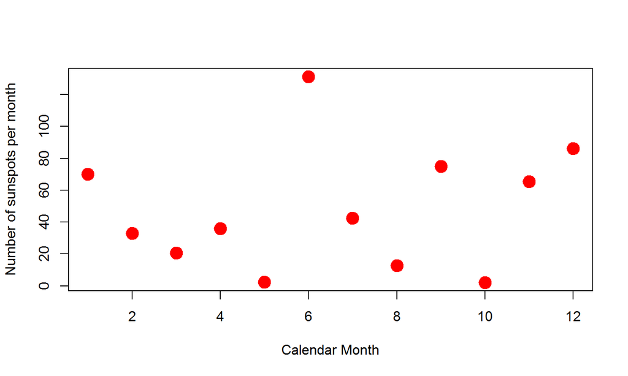

1st plot: choose a year (here: 1751)

```r
sunspotsbymonth<-matrix(sunspots, ncol=13)
plot(sunspotsbymonth[3,], xlim=c(1,12), xlab="Calendar Month",
         ylab="Number of sunspots per month", pch=19, cex=2, col="red")
```

## Plot examples - choose a month

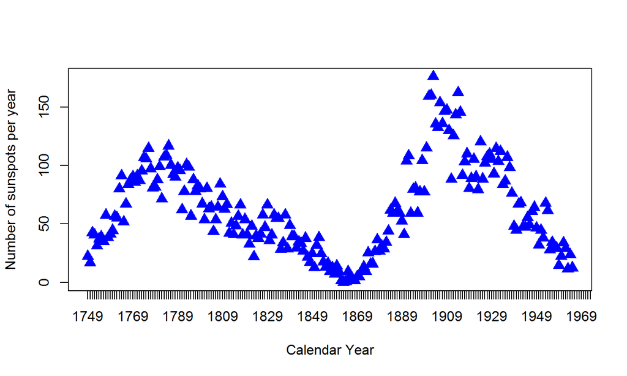

2nd plot: choose a month (here July)

```r
sunspotsbymonth<-matrix(sunspots, ncol=13)
plot(sunspotsbymonth[,7], xlab="Calendar Year", xaxt="n",
        ylab="Number of sunspots per year", pch=17, cex=1.5, col="blue")
    axis(1, at=1:235, labels=c(1749:1983))
```

## Conclusions

- **Interactive** Shiny app available at: https://justgo129.shinyapps.io/course9project/
- Looking forward to your view!